# First Pass: college_major_roi.csv

**Run Timestamp:** 2026-10-04 16:36:18 **First Pass Version:** 1.1.0

## Input Summary

- **File:** C:\Users\arvin\Desktop\Sample Datasets\college_major_roi.csv
- **Shape:** 30000 rows, 18 columns

## Raw Data Profile

```python
%matplotlib inline
import pandas as pd
import matplotlib.pyplot as plt
import seaborn as sns
import warnings
warnings.filterwarnings('ignore')
sns.set_theme(style='whitegrid', palette='deep')
from IPython.display import display
from first_pass.ingest import load_spreadsheet
df = load_spreadsheet('C:/Users/arvin/Desktop/Sample Datasets/college_major_roi.csv')
display(df.head())
df.info()
```

|  | grad_id | major | major_category | institution_tier | institution_selectivity_pctile | gpa | had_internship | completed_on_time | region | net_cost_usd | debt_usd | hs_baseline_10yr_usd | added_earnings_10yr_usd | earnings_10yr_usd | net_roi_usd | roi_pct | positive_roi | high_roi |
| --- | --- | --- | --- | --- | --- | --- | --- | --- | --- | --- | --- | --- | --- | --- | --- | --- | --- | --- |
| 0 | G000000 | biology | STEM | mid_tier | 52 | 2.58 | 0 | 0 | south | 144400 | 0 | 411700 | 101000 | 512700 | -43400 | -30.0 | 0 | 0 |
| 1 | G000001 | marketing | business | mid_tier | 61 | 2.58 | 0 | 1 | northeast | 57400 | 0 | 356900 | 330600 | 687500 | 273200 | 476.1 | 1 | 0 |
| 2 | G000002 | electrical_engineering | STEM | top_public | 78 | 3.14 | 1 | 1 | northeast | 65100 | 39600 | 339600 | 655100 | 994700 | 590000 | 906.4 | 1 | 1 |
| 3 | G000003 | marketing | business | top_public | 77 | 3.04 | 0 | 1 | midwest | 105800 | 81300 | 399600 | 197500 | 597100 | 91700 | 86.8 | 1 | 0 |
| 4 | G000004 | marketing | business | ivy_elite | 100 | 3.81 | 0 | 0 | south | 219200 | 93500 | 335700 | 222900 | 558600 | 3800 | 1.7 | 1 | 0 |

```
<class 'pandas.core.frame.DataFrame'>
RangeIndex: 30000 entries, 0 to 29999
Data columns (total 18 columns):
 #   Column                          Non-Null Count  Dtype
---  ------                          --------------  -----
 0   grad_id                         30000 non-null  object
 1   major                           30000 non-null  object
 2   major_category                  30000 non-null  object
 3   institution_tier                30000 non-null  object
 4   institution_selectivity_pctile  30000 non-null  int64
 5   gpa                             30000 non-null  float64
 6   had_internship                  30000 non-null  int64
 7   completed_on_time               30000 non-null  int64
 8   region                          30000 non-null  object
 9   net_cost_usd                    30000 non-null  int64
 10  debt_usd                        30000 non-null  int64
 11  hs_baseline_10yr_usd            30000 non-null  int64
 12  added_earnings_10yr_usd         30000 non-null  int64
 13  earnings_10yr_usd               30000 non-null  int64
 14  net_roi_usd                     30000 non-null  int64
 15  roi_pct                         30000 non-null  float64
 16  positive_roi                    30000 non-null  int64
 17  high_roi                        30000 non-null  int64
dtypes: float64(2), int64(11), object(5)
memory usage: 4.1+ MB
```

## Cleaning Plan

No cleaning steps planned.

## Cleaned Data Profile

```python
display(df.head())
df.info()
```

|  | grad_id | major | major_category | institution_tier | institution_selectivity_pctile | gpa | had_internship | completed_on_time | region | net_cost_usd | debt_usd | hs_baseline_10yr_usd | added_earnings_10yr_usd | earnings_10yr_usd | net_roi_usd | roi_pct | positive_roi | high_roi |
| --- | --- | --- | --- | --- | --- | --- | --- | --- | --- | --- | --- | --- | --- | --- | --- | --- | --- | --- |
| 0 | G000000 | biology | STEM | mid_tier | 52 | 2.58 | 0 | 0 | south | 144400 | 0 | 411700 | 101000 | 512700 | -43400 | -30.0 | 0 | 0 |
| 1 | G000001 | marketing | business | mid_tier | 61 | 2.58 | 0 | 1 | northeast | 57400 | 0 | 356900 | 330600 | 687500 | 273200 | 476.1 | 1 | 0 |
| 2 | G000002 | electrical_engineering | STEM | top_public | 78 | 3.14 | 1 | 1 | northeast | 65100 | 39600 | 339600 | 655100 | 994700 | 590000 | 906.4 | 1 | 1 |
| 3 | G000003 | marketing | business | top_public | 77 | 3.04 | 0 | 1 | midwest | 105800 | 81300 | 399600 | 197500 | 597100 | 91700 | 86.8 | 1 | 0 |
| 4 | G000004 | marketing | business | ivy_elite | 100 | 3.81 | 0 | 0 | south | 219200 | 93500 | 335700 | 222900 | 558600 | 3800 | 1.7 | 1 | 0 |

```
<class 'pandas.core.frame.DataFrame'>
RangeIndex: 30000 entries, 0 to 29999
Data columns (total 18 columns):
 #   Column                          Non-Null Count  Dtype
---  ------                          --------------  -----
 0   grad_id                         30000 non-null  object
 1   major                           30000 non-null  object
 2   major_category                  30000 non-null  object
 3   institution_tier                30000 non-null  object
 4   institution_selectivity_pctile  30000 non-null  int64
 5   gpa                             30000 non-null  float64
 6   had_internship                  30000 non-null  int64
 7   completed_on_time               30000 non-null  int64
 8   region                          30000 non-null  object
 9   net_cost_usd                    30000 non-null  int64
 10  debt_usd                        30000 non-null  int64
 11  hs_baseline_10yr_usd            30000 non-null  int64
 12  added_earnings_10yr_usd         30000 non-null  int64
 13  earnings_10yr_usd               30000 non-null  int64
 14  net_roi_usd                     30000 non-null  int64
 15  roi_pct                         30000 non-null  float64
 16  positive_roi                    30000 non-null  int64
 17  high_roi                        30000 non-null  int64
dtypes: float64(2), int64(11), object(5)
memory usage: 4.1+ MB
```

## Export Cleaned Data

```python
try:
    df.to_csv('temp/college_major_roi_Validation_cleaned.csv', index=False)
    df.to_excel('temp/college_major_roi_Validation_cleaned.xlsx', index=False)
    df.to_parquet('temp/college_major_roi_Validation_cleaned.parquet', index=False)
    # Manual xls export since pandas dropped it
    import xlwt
    wb = xlwt.Workbook()
    ws = wb.add_sheet('Sheet1')
    import csv
    with open('temp/college_major_roi_Validation_cleaned.csv', 'r', encoding='utf-8') as f:
        for r, row in enumerate(csv.reader(f)):
            for c, val in enumerate(row):
                ws.write(r, c, val)
    wb.save('temp/college_major_roi_Validation_cleaned.xls')
except Exception as e:
    print(f'Error saving dataset: {e}')
```

## Analysis Plan

**Target Variables:** net_roi_usd, roi_pct, earnings_10yr_usd

### Section 1: Data Overview

High-level summary of data types, summary statistics, and missing values.

| Step | Columns | Template | Rationale | Playbooks |
| --- | --- | --- | --- | --- |
| 1 |  | `column_overview` | Overview of column types and missing values. |  |
| 2 |  | `summary_stats` | High-level summary statistics of all columns. |  |

### Section 2: Return on Investment & Earnings Premium Across Majors

Evaluate which degree programs deliver the strongest financial returns relative to baseline earnings and education costs.

| Step | Columns | Template | Rationale | Playbooks |
| --- | --- | --- | --- | --- |
| 1 | major_category, net_roi_usd | `custom_code` | Identifies fields of study that maximize long-term wealth creation versus categories at risk of negative returns. | custom_code |
| 2 | major, net_roi_usd, positive_roi | `custom_code` | Compares absolute financial reward against probability of achieving positive ROI across all 19 tracked majors. | custom_code |

### Section 3: Institutional Value & Cost Dynamics

Assess whether prestigious institutional tiers and higher net tuition deliver proportional earnings premiums or excessive debt burden.

| Step | Columns | Template | Rationale | Playbooks |
| --- | --- | --- | --- | --- |
| 1 | institution_tier, net_cost_usd, debt_usd, earnings_10yr_usd | `custom_code` | Quantifies if elite and top-tier institutions provide a commensurate earnings premium given student debt load. | custom_code |
| 2 | institution_selectivity_pctile, earnings_10yr_usd, major_category | `custom_code` | Measures the linear return on selectivity percentile to understand how much admissions selectivity alone boosts graduate earnings. | custom_code |

### Section 4: Student-Level Levers: Academic Performance & Career Experience

Isolate actionable student behaviors including GPA, internships, and on-time completion on overall financial outcomes.

| Step | Columns | Template | Rationale | Playbooks |
| --- | --- | --- | --- | --- |
| 1 | had_internship, completed_on_time, earnings_10yr_usd | `custom_code` | Quantifies the compounding interaction of practical work experience and timely degree completion on market earnings. | custom_code |
| 2 | gpa, roi_pct, major_category | `custom_code` | Assesses whether academic performance yields uniform returns or if technical/business disciplines capture disproportionate gains. | custom_code |

## 1. Data Overview

High-level summary of data types, summary statistics, and missing values.

### Column Overview

Overview of column types and missing values.

```python
try:
    display(df.dtypes)
except Exception as e:
    print(f'\nError executing column_overview: {e}')
```

```
grad_id                            object
major                              object
major_category                     object
institution_tier                   object
institution_selectivity_pctile      int64
gpa                               float64
had_internship                      int64
completed_on_time                   int64
region                             object
net_cost_usd                        int64
debt_usd                            int64
hs_baseline_10yr_usd                int64
added_earnings_10yr_usd             int64
earnings_10yr_usd                   int64
net_roi_usd                         int64
roi_pct                           float64
positive_roi                        int64
high_roi                            int64
dtype: object
```

### Summary Statistics

High-level summary statistics of all columns.

```python
try:
    display(df.describe(include='all'))
except Exception as e:
    print(f'\nError executing summary_stats: {e}')
```

|  | grad_id | major | major_category | institution_tier | institution_selectivity_pctile | gpa | had_internship | completed_on_time | region | net_cost_usd | debt_usd | hs_baseline_10yr_usd | added_earnings_10yr_usd | earnings_10yr_usd | net_roi_usd | roi_pct | positive_roi | high_roi |
| --- | --- | --- | --- | --- | --- | --- | --- | --- | --- | --- | --- | --- | --- | --- | --- | --- | --- | --- |
| count | 30000 | 30000 | 30000 | 30000 | 30000.000000 | 30000.000000 | 30000.000000 | 30000.000000 | 30000 | 30000.000000 | 30000.000000 | 30000.000000 | 3.000000e+04 | 3.000000e+04 | 3.000000e+04 | 30000.000000 | 30000.000000 | 30000.00000 |
| unique | 30000 | 19 | 7 | 5 | NaN | NaN | NaN | NaN | 4 | NaN | NaN | NaN | NaN | NaN | NaN | NaN | NaN | NaN |
| top | G029983 | communications | STEM | mid_tier | NaN | NaN | NaN | NaN | south | NaN | NaN | NaN | NaN | NaN | NaN | NaN | NaN | NaN |
| freq | 1 | 1788 | 9904 | 10258 | NaN | NaN | NaN | NaN | 9488 | NaN | NaN | NaN | NaN | NaN | NaN | NaN | NaN | NaN |
| mean | NaN | NaN | NaN | NaN | 55.086067 | 3.093337 | 0.436067 | 0.682367 | NaN | 88621.496667 | 38498.063333 | 359893.416667 | 3.554752e+05 | 7.153680e+05 | 2.668537e+05 | 346.153987 | 0.835167 | 0.25000 |
| std | NaN | NaN | NaN | NaN | 18.593708 | 0.439060 | 0.495904 | 0.465564 | NaN | 33576.903160 | 37801.748200 | 39923.943255 | 2.948109e+05 | 2.977847e+05 | 2.949958e+05 | 398.666879 | 0.371036 | 0.43302 |
| min | NaN | NaN | NaN | NaN | 16.000000 | 1.500000 | 0.000000 | 0.000000 | NaN | 28500.000000 | 0.000000 | 250000.000000 | 1.000000e+04 | 2.723000e+05 | -3.052000e+05 | -92.100000 | 0.000000 | 0.00000 |
| 25% | NaN | NaN | NaN | NaN | 42.000000 | 2.790000 | 0.000000 | 0.000000 | NaN | 65500.000000 | 0.000000 | 333100.000000 | 1.179000e+05 | 4.835000e+05 | 3.280000e+04 | 39.700000 | 1.000000 | 0.00000 |
| 50% | NaN | NaN | NaN | NaN | 55.000000 | 3.100000 | 0.000000 | 1.000000 | NaN | 81000.000000 | 38700.000000 | 359700.000000 | 2.836500e+05 | 6.458000e+05 | 1.981000e+05 | 230.900000 | 1.000000 | 0.00000 |
| 75% | NaN | NaN | NaN | NaN | 68.000000 | 3.400000 | 1.000000 | 1.000000 | NaN | 103600.000000 | 62300.000000 | 387300.000000 | 5.093000e+05 | 8.717000e+05 | 4.235250e+05 | 537.400000 | 1.000000 | 0.25000 |
| max | NaN | NaN | NaN | NaN | 102.000000 | 4.000000 | 1.000000 | 1.000000 | NaN | 352900.000000 | 331700.000000 | 480000.000000 | 2.894900e+06 | 3.245500e+06 | 2.755100e+06 | 3618.900000 | 1.000000 | 1.00000 |

## 2. Return on Investment & Earnings Premium Across Majors

Evaluate which degree programs deliver the strongest financial returns relative to baseline earnings and education costs.

### Which major categories deliver the highest 10-year net ROI?

Identifies fields of study that maximize long-term wealth creation versus categories at risk of negative returns.

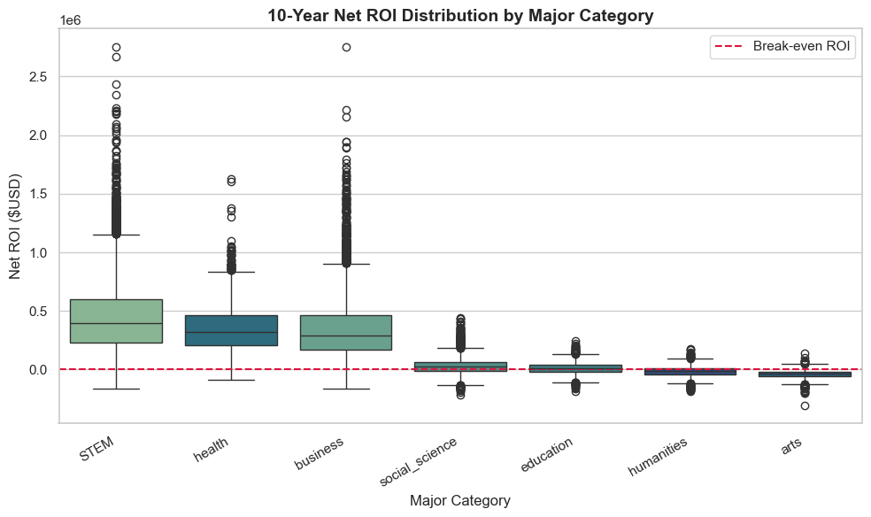

```python
try:
    fig, ax = plt.subplots(figsize=(10, 6))
    order = df.groupby('major_category')['net_roi_usd'].median().sort_values(ascending=False).index
    sns.boxplot(data=df, x='major_category', y='net_roi_usd', order=order, hue='major_category', palette='crest', legend=False, ax=ax)
    ax.axhline(0, color='crimson', linestyle='--', linewidth=1.5, label='Break-even ROI')
    ax.set_title('10-Year Net ROI Distribution by Major Category', fontsize=14, fontweight='bold')
    ax.set_xlabel('Major Category', fontsize=12)
    ax.set_ylabel('Net ROI ($USD)', fontsize=12)
    ax.legend()
    plt.xticks(rotation=30, ha='right')
    plt.tight_layout()
    plt.show()
except Exception as e:
    print(f'\nError executing custom_code: {e}')
```

### Granular ROI and risk profile: Median return vs downside risk across specific majors

Compares absolute financial reward against probability of achieving positive ROI across all 19 tracked majors.

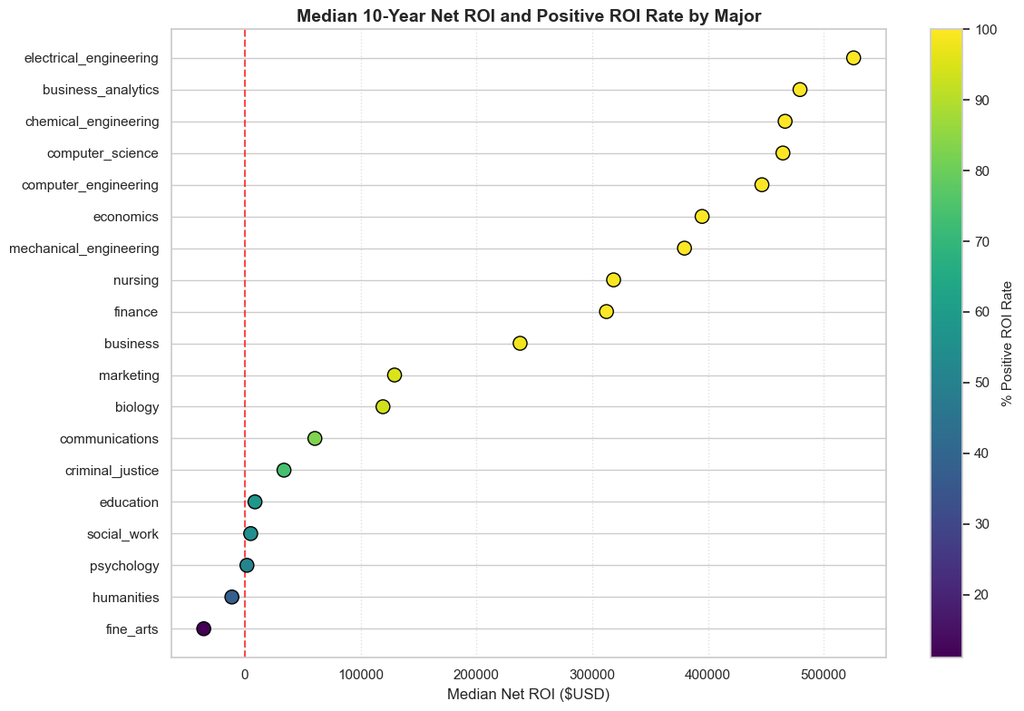

```python
try:
    major_summary = df.groupby('major').agg(median_roi=('net_roi_usd', 'median'), positive_rate=('positive_roi', 'mean')).reset_index().sort_values('median_roi', ascending=True)
    fig, ax = plt.subplots(figsize=(12, 8))
    scatter = ax.scatter(major_summary['median_roi'], major_summary['major'], c=major_summary['positive_rate'] * 100, cmap='viridis', s=120, edgecolors='black', zorder=3)
    cbar = plt.colorbar(scatter, ax=ax)
    cbar.set_label('% Positive ROI Rate', fontsize=11)
    ax.axvline(0, color='red', linestyle='--', alpha=0.7)
    ax.set_title('Median 10-Year Net ROI and Positive ROI Rate by Major', fontsize=14, fontweight='bold')
    ax.set_xlabel('Median Net ROI ($USD)', fontsize=12)
    ax.grid(axis='x', linestyle=':', alpha=0.6)
    plt.tight_layout()
    plt.show()
except Exception as e:
    print(f'\nError executing custom_code: {e}')
```

**Insight:** This chart illustrates a near-perfect monotonic relationship between median 10-year net ROI and the likelihood of achieving a positive financial return, ranging from fine arts (under -$30,000 median ROI, <15% positive rate) to electrical engineering (over $500,000 median ROI, ~100% positive rate). High-return quantitative majors virtually guarantee break-even outcomes, whereas graduates in arts, humanities, and social work face a systematic risk of negative financial return. These insights are critical for academic policymakers and financial aid counselors to mandate transparent disclosure of program-level earnings before students incur non-dischargeable debt.

## 3. Institutional Value & Cost Dynamics

Assess whether prestigious institutional tiers and higher net tuition deliver proportional earnings premiums or excessive debt burden.

### Does institutional tier justify cumulative debt and net tuition cost?

Quantifies if elite and top-tier institutions provide a commensurate earnings premium given student debt load.

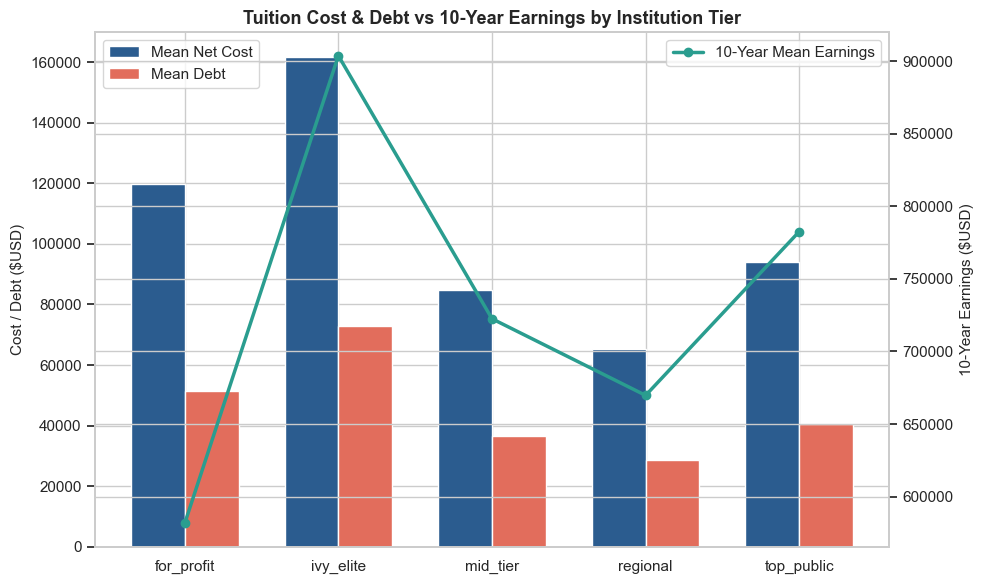

```python
try:
    tier_agg = df.groupby('institution_tier').agg(mean_cost=('net_cost_usd', 'mean'), mean_debt=('debt_usd', 'mean'), mean_earnings=('earnings_10yr_usd', 'mean')).reset_index()
    fig, ax1 = plt.subplots(figsize=(10, 6))
    ax2 = ax1.twinx()
    x = range(len(tier_agg))
    width = 0.35
    ax1.bar([i - width/2 for i in x], tier_agg['mean_cost'], width=width, label='Mean Net Cost', color='#2b5c8f')
    ax1.bar([i + width/2 for i in x], tier_agg['mean_debt'], width=width, label='Mean Debt', color='#e26d5c')
    ax2.plot(x, tier_agg['mean_earnings'], color='#2a9d8f', marker='o', linewidth=2.5, label='10-Year Mean Earnings')
    ax1.set_xticks(x)
    ax1.set_xticklabels(tier_agg['institution_tier'])
    ax1.set_ylabel('Cost / Debt ($USD)', fontsize=11)
    ax2.set_ylabel('10-Year Earnings ($USD)', fontsize=11)
    ax1.set_title('Tuition Cost & Debt vs 10-Year Earnings by Institution Tier', fontsize=13, fontweight='bold')
    ax1.legend(loc='upper left')
    ax2.legend(loc='upper right')
    plt.tight_layout()
    plt.show()
except Exception as e:
    print(f'\nError executing custom_code: {e}')
```

### Institutional selectivity percentile vs 10-year earnings trajectory

Measures the linear return on selectivity percentile to understand how much admissions selectivity alone boosts graduate earnings.

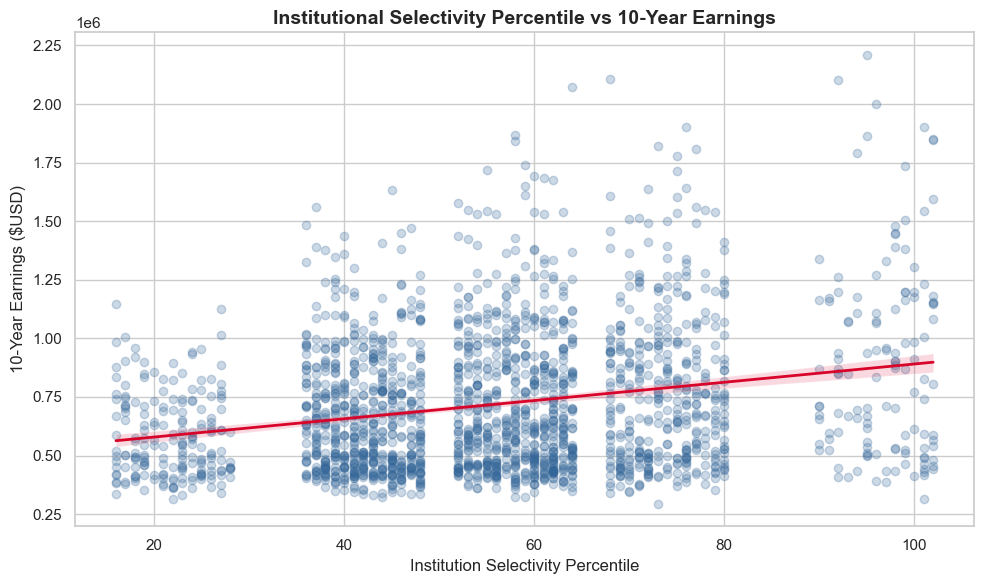

```python
try:
    fig, ax = plt.subplots(figsize=(10, 6))
    sns.regplot(data=df.sample(2000, random_state=42), x='institution_selectivity_pctile', y='earnings_10yr_usd', scatter_kws={'alpha': 0.25, 'color': '#336699'}, line_kws={'color': '#d90429', 'linewidth': 2}, ax=ax)
    ax.set_title('Institutional Selectivity Percentile vs 10-Year Earnings', fontsize=14, fontweight='bold')
    ax.set_xlabel('Institution Selectivity Percentile', fontsize=12)
    ax.set_ylabel('10-Year Earnings ($USD)', fontsize=12)
    plt.tight_layout()
    plt.show()
except Exception as e:
    print(f'\nError executing custom_code: {e}')
```

**Insight:** The regression analysis indicates a modest positive relationship between institutional selectivity and 10-year post-graduation earnings, moving expected earnings from roughly $600,000 to just under $900,000 across percentiles. However, the substantial variance across all selectivity tiers demonstrates that school prestige alone does not guarantee superior financial outcomes. Strategic educational investments must weigh individual program choice and career readiness far more heavily than relying solely on the institutional brand name.

## 4. Student-Level Levers: Academic Performance & Career Experience

Isolate actionable student behaviors including GPA, internships, and on-time completion on overall financial outcomes.

### What is the earnings premium of internships and on-time graduation?

Quantifies the compounding interaction of practical work experience and timely degree completion on market earnings.

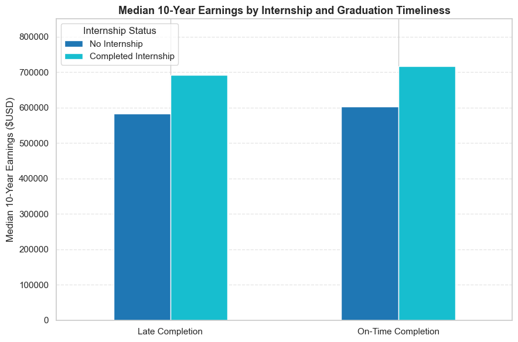

```python
try:
    fig, ax = plt.subplots(figsize=(9, 6))
    summary = df.groupby(['completed_on_time', 'had_internship'])['earnings_10yr_usd'].median().unstack()
    summary.index = ['Late Completion', 'On-Time Completion']
    summary.columns = ['No Internship', 'Completed Internship']
    summary.plot(kind='bar', ax=ax, colormap='tab10', rot=0)
    ax.set_title('Median 10-Year Earnings by Internship and Graduation Timeliness', fontsize=13, fontweight='bold')
    ax.set_ylabel('Median 10-Year Earnings ($USD)', fontsize=12)
    ax.set_ylim(0, 850000)
    ax.legend(title='Internship Status', loc='upper left')
    ax.grid(axis='y', linestyle='--', alpha=0.5)
    plt.tight_layout()
    plt.show()
except Exception as e:
    print(f'\nError executing custom_code: {e}')
```

**Insight:** This analysis reveals that completing an internship delivers a dramatic earnings premium of over $110,000 across both late and on-time graduates, far outweighing the modest ~$20,000 premium associated with timely completion alone. Practical industry experience serves as the single most powerful behavioral driver of early-career earnings realization identified in the data. Universities aiming to improve their value proposition should mandate or deeply subsidize structured internship programs to drive immediate graduate employability.

### Does GPA correlate with ROI across different major categories?

Assesses whether academic performance yields uniform returns or if technical/business disciplines capture disproportionate gains.

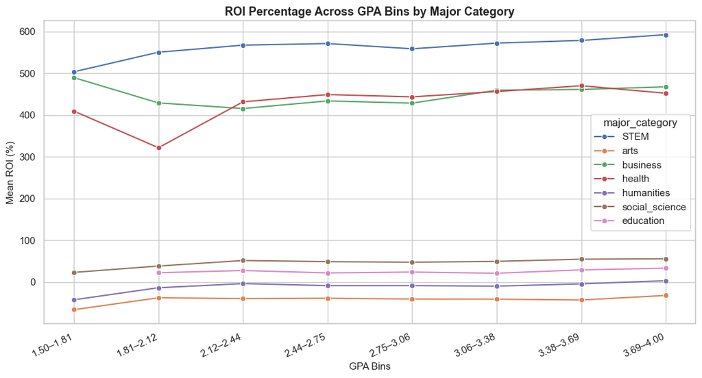

```python
try:
    fig, ax = plt.subplots(figsize=(11, 6))
    df_temp = df.copy()
    categories = pd.cut(df_temp['gpa'], bins=8).cat.categories
    labels = [f'{c.left:.2f}–{c.right:.2f}' for c in categories]
    df_temp['gpa_bin'] = pd.cut(df_temp['gpa'], bins=8, labels=labels)
    summary = df_temp.groupby(['gpa_bin', 'major_category'], observed=True)['roi_pct'].mean().reset_index()
    sns.lineplot(data=summary, x='gpa_bin', y='roi_pct', hue='major_category', marker='o', ax=ax)
    ax.set_title('ROI Percentage Across GPA Bins by Major Category', fontsize=13, fontweight='bold')
    ax.set_xlabel('GPA Bins', fontsize=11)
    ax.set_ylabel('Mean ROI (%)', fontsize=11)
    plt.xticks(rotation=25, ha='right')
    plt.tight_layout()
    plt.show()
except Exception as e:
    print(f'\nError executing custom_code: {e}')
```

**Insight:** The trend lines show that mean ROI percentages remain largely flat across all GPA brackets, confirming that academic grade performance does not compensate for the structural labor-market valuation of a major. A low-GPA graduate in STEM or business still commands an ROI hundreds of percentage points higher than a top-performing student in arts or humanities. This finding indicates that strategic career navigation, domain selection, and practical experience are significantly more determinant of economic mobility than marginal improvements in classroom GPA.

## Further Analyses to Consider

The following analyses were considered relevant but skipped to keep this first pass concise.

| Tool | Columns | Rationale |
| --- | --- | --- |
| `custom_code` | major, institution_tier, debt_usd, net_roi_usd | Train an explainable multivariate regression or gradient boosted model to assess feature importance and predict debt-to-income default risk. |
| `custom_code` | region, hs_baseline_10yr_usd, earnings_10yr_usd | Perform regional cost-of-living adjustments on high-school baseline versus college earnings to benchmark localized net wage premiums. |

## Appendix

### Raw Cleaning Plan JSON

```
{
  "steps": []
}
```

### Raw Analysis Plan JSON

```
{
  "target_variables": [
    "net_roi_usd",
    "roi_pct",
    "earnings_10yr_usd"
  ],
  "sections": [
    {
      "title": "Data Overview",
      "description": "High-level summary of data types, summary statistics, and missing values.",
      "analyses": [
        {
          "title": "Column Overview",
          "template_id": "column_overview",
          "columns": [],
          "params": "{}",
          "rationale": "Overview of column types and missing values.",
          "playbook_ids": []
        },
        {
          "title": "Summary Statistics",
          "template_id": "summary_stats",
          "columns": [],
          "params": "{}",
          "rationale": "High-level summary statistics of all columns.",
          "playbook_ids": []
        }
      ]
    },
    {
      "title": "Return on Investment & Earnings Premium Across Majors",
      "description": "Evaluate which degree programs deliver the strongest financial returns relative to baseline earnings and education costs.",
      "analyses": [
        {
          "title": "Which major categories deliver the highest 10-year net ROI?",
          "template_id": "custom_code",
          "columns": [
            "major_category",
            "net_roi_usd"
          ],
          "params": "{\"code_snippet\": \"fig, ax = plt.subplots(figsize=(10, 6))\\norder = df.groupby('major_category')['net_roi_usd'].median().sort_values(ascending=False).index\\nsns.boxplot(data=df, x='major_category', y='net_roi_usd', order=order, hue='major_category', palette='crest', legend=False, ax=ax)\\nax.axhline(0, color='crimson', linestyle='--', linewidth=1.5, label='Break-even ROI')\\nax.set_title('10-Year Net ROI Distribution by Major Category', fontsize=14, fontweight='bold')\\nax.set_xlabel('Major Category', fontsize=12)\\nax.set_ylabel('Net ROI ($USD)', fontsize=12)\\nax.legend()\\nplt.xticks(rotation=30, ha='right')\\nplt.tight_layout()\"}",
          "rationale": "Identifies fields of study that maximize long-term wealth creation versus categories at risk of negative returns.",
          "playbook_ids": [
            "custom_code"
          ]
        },
        {
          "title": "Granular ROI and risk profile: Median return vs downside risk across specific majors",
          "template_id": "custom_code",
          "columns": [
            "major",
            "net_roi_usd",
            "positive_roi"
          ],
          "params": "{\"code_snippet\": \"major_summary = df.groupby('major').agg(median_roi=('net_roi_usd', 'median'), positive_rate=('positive_roi', 'mean')).reset_index().sort_values('median_roi', ascending=True)\\nfig, ax = plt.subplots(figsize=(12, 8))\\nscatter = ax.scatter(major_summary['median_roi'], major_summary['major'], c=major_summary['positive_rate'] * 100, cmap='viridis', s=120, edgecolors='black', zorder=3)\\ncbar = plt.colorbar(scatter, ax=ax)\\ncbar.set_label('% Positive ROI Rate', fontsize=11)\\nax.axvline(0, color='red', linestyle='--', alpha=0.7)\\nax.set_title('Median 10-Year Net ROI and Positive ROI Rate by Major', fontsize=14, fontweight='bold')\\nax.set_xlabel('Median Net ROI ($USD)', fontsize=12)\\nax.grid(axis='x', linestyle=':', alpha=0.6)\\nplt.tight_layout()\"}",
          "rationale": "Compares absolute financial reward against probability of achieving positive ROI across all 19 tracked majors.",
          "playbook_ids": [
            "custom_code"
          ]
        }
      ]
    },
    {
      "title": "Institutional Value & Cost Dynamics",
      "description": "Assess whether prestigious institutional tiers and higher net tuition deliver proportional earnings premiums or excessive debt burden.",
      "analyses": [
        {
          "title": "Does institutional tier justify cumulative debt and net tuition cost?",
          "template_id": "custom_code",
          "columns": [
            "institution_tier",
            "net_cost_usd",
            "debt_usd",
            "earnings_10yr_usd"
          ],
          "params": "{\"code_snippet\": \"tier_agg = df.groupby('institution_tier').agg(mean_cost=('net_cost_usd', 'mean'), mean_debt=('debt_usd', 'mean'), mean_earnings=('earnings_10yr_usd', 'mean')).reset_index()\\nfig, ax1 = plt.subplots(figsize=(10, 6))\\nax2 = ax1.twinx()\\nx = range(len(tier_agg))\\nwidth = 0.35\\nax1.bar([i - width/2 for i in x], tier_agg['mean_cost'], width=width, label='Mean Net Cost', color='#2b5c8f')\\nax1.bar([i + width/2 for i in x], tier_agg['mean_debt'], width=width, label='Mean Debt', color='#e26d5c')\\nax2.plot(x, tier_agg['mean_earnings'], color='#2a9d8f', marker='o', linewidth=2.5, label='10-Year Mean Earnings')\\nax1.set_xticks(x)\\nax1.set_xticklabels(tier_agg['institution_tier'])\\nax1.set_ylabel('Cost / Debt ($USD)', fontsize=11)\\nax2.set_ylabel('10-Year Earnings ($USD)', fontsize=11)\\nax1.set_title('Tuition Cost & Debt vs 10-Year Earnings by Institution Tier', fontsize=13, fontweight='bold')\\nax1.legend(loc='upper left')\\nax2.legend(loc='upper right')\\nplt.tight_layout()\"}",
          "rationale": "Quantifies if elite and top-tier institutions provide a commensurate earnings premium given student debt load.",
          "playbook_ids": [
            "custom_code"
          ]
        },
        {
          "title": "Institutional selectivity percentile vs 10-year earnings trajectory",
          "template_id": "custom_code",
          "columns": [
            "institution_selectivity_pctile",
            "earnings_10yr_usd",
            "major_category"
          ],
          "params": "{\"code_snippet\": \"fig, ax = plt.subplots(figsize=(10, 6))\\nsns.regplot(data=df.sample(2000, random_state=42), x='institution_selectivity_pctile', y='earnings_10yr_usd', scatter_kws={'alpha': 0.25, 'color': '#336699'}, line_kws={'color': '#d90429', 'linewidth': 2}, ax=ax)\\nax.set_title('Institutional Selectivity Percentile vs 10-Year Earnings', fontsize=14, fontweight='bold')\\nax.set_xlabel('Institution Selectivity Percentile', fontsize=12)\\nax.set_ylabel('10-Year Earnings ($USD)', fontsize=12)\\nplt.tight_layout()\"}",
          "rationale": "Measures the linear return on selectivity percentile to understand how much admissions selectivity alone boosts graduate earnings.",
          "playbook_ids": [
            "custom_code"
          ]
        }
      ]
    },
    {
      "title": "Student-Level Levers: Academic Performance & Career Experience",
      "description": "Isolate actionable student behaviors including GPA, internships, and on-time completion on overall financial outcomes.",
      "analyses": [
        {
          "title": "What is the earnings premium of internships and on-time graduation?",
          "template_id": "custom_code",
          "columns": [
            "had_internship",
            "completed_on_time",
            "earnings_10yr_usd"
          ],
          "params": "{\"code_snippet\": \"fig, ax = plt.subplots(figsize=(9, 6))\\nsummary = df.groupby(['completed_on_time', 'had_internship'])['earnings_10yr_usd'].median().unstack()\\nsummary.index = ['Late Completion', 'On-Time Completion']\\nsummary.columns = ['No Internship', 'Completed Internship']\\nsummary.plot(kind='bar', ax=ax, colormap='tab10', rot=0)\\nax.set_title('Median 10-Year Earnings by Internship and Graduation Timeliness', fontsize=13, fontweight='bold')\\nax.set_ylabel('Median 10-Year Earnings ($USD)', fontsize=12)\\nax.legend(title='Internship Status')\\nax.grid(axis='y', linestyle='--', alpha=0.5)\\nplt.tight_layout()\"}",
          "rationale": "Quantifies the compounding interaction of practical work experience and timely degree completion on market earnings.",
          "playbook_ids": [
            "custom_code"
          ]
        },
        {
          "title": "Does GPA correlate with ROI across different major categories?",
          "template_id": "custom_code",
          "columns": [
            "gpa",
            "roi_pct",
            "major_category"
          ],
          "params": "{\"code_snippet\": \"fig, ax = plt.subplots(figsize=(11, 6))\\nsns.lineplot(data=df, x=pd.cut(df['gpa'], bins=8), y='roi_pct', hue='major_category', errorbar=None, marker='o', ax=ax)\\nax.set_title('ROI Percentage Across GPA Bins by Major Category', fontsize=13, fontweight='bold')\\nax.set_xlabel('GPA Bins', fontsize=11)\\nax.set_ylabel('Mean ROI (%)', fontsize=11)\\nplt.xticks(rotation=25, ha='right')\\nplt.tight_layout()\"}",
          "rationale": "Assesses whether academic performance yields uniform returns or if technical/business disciplines capture disproportionate gains.",
          "playbook_ids": [
            "custom_code"
          ]
        }
      ]
    }
  ],
  "further_analyses": [
    {
      "template_id": "custom_code",
      "columns": [
        "major",
        "institution_tier",
        "debt_usd",
        "net_roi_usd"
      ],
      "rationale": "Train an explainable multivariate regression or gradient boosted model to assess feature importance and predict debt-to-income default risk."
    },
    {
      "template_id": "custom_code",
      "columns": [
        "region",
        "hs_baseline_10yr_usd",
        "earnings_10yr_usd"
      ],
      "rationale": "Perform regional cost-of-living adjustments on high-school baseline versus college earnings to benchmark localized net wage premiums."
    }
  ]
}
```